# DATA ANALYSIS AND VIZUALIZATION ON SUPER STORE DATA

### IMPORT LIBRARIES

```python
import pandas as pd
import numpy as np
import matplotlib.pyplot as plt
import seaborn as sns
import plotly.express as px
```

The libraries here are mainly for data frame management and visulizations

### DATA LOADING

```python
df = pd.read_csv("Global-Superstore - Global-Superstore.csv.csv")
df
```

|  | Row ID | Order ID | Order Date | Ship Date | Ship Mode | Customer ID | Customer Name | Segment | City | State | ... | Product ID | Category | Sub-Category | Product Name | Sales | Quantity | Discount | Profit | Shipping Cost | Order Priority |
| --- | --- | --- | --- | --- | --- | --- | --- | --- | --- | --- | --- | --- | --- | --- | --- | --- | --- | --- | --- | --- | --- |
| 0 | 32298 | CA-2012-124891 | 7/31/2012 | 7/31/2012 | Same Day | RH-19495 | Rick Hansen | Consumer | New York City | New York | ... | TEC-AC-10003033 | Technology | Accessories | Plantronics CS510 - Over-the-Head monaural Wir... | 2309.650 | 7 | 0.0 | 762.1845 | 933.57 | Critical |
| 1 | 26341 | IN-2013-77878 | 2/5/2013 | 2/7/2013 | Second Class | JR-16210 | Justin Ritter | Corporate | Wollongong | New South Wales | ... | FUR-CH-10003950 | Furniture | Chairs | Novimex Executive Leather Armchair, Black | 3709.395 | 9 | 0.1 | -288.7650 | 923.63 | Critical |
| 2 | 25330 | IN-2013-71249 | 10/17/2013 | 10/18/2013 | First Class | CR-12730 | Craig Reiter | Consumer | Brisbane | Queensland | ... | TEC-PH-10004664 | Technology | Phones | Nokia Smart Phone, with Caller ID | 5175.171 | 9 | 0.1 | 919.9710 | 915.49 | Medium |
| 3 | 13524 | ES-2013-1579342 | 1/28/2013 | 1/30/2013 | First Class | KM-16375 | Katherine Murray | Home Office | Berlin | Berlin | ... | TEC-PH-10004583 | Technology | Phones | Motorola Smart Phone, Cordless | 2892.510 | 5 | 0.1 | -96.5400 | 910.16 | Medium |
| 4 | 47221 | SG-2013-4320 | 11/5/2013 | 11/6/2013 | Same Day | RH-9495 | Rick Hansen | Consumer | Dakar | Dakar | ... | TEC-SHA-10000501 | Technology | Copiers | Sharp Wireless Fax, High-Speed | 2832.960 | 8 | 0.0 | 311.5200 | 903.04 | Critical |
| ... | ... | ... | ... | ... | ... | ... | ... | ... | ... | ... | ... | ... | ... | ... | ... | ... | ... | ... | ... | ... | ... |
| 51285 | 29002 | IN-2014-62366 | 6/19/2014 | 6/19/2014 | Same Day | KE-16420 | Katrina Edelman | Corporate | Kure | Hiroshima | ... | OFF-FA-10000746 | Office Supplies | Fasteners | Advantus Thumb Tacks, 12 Pack | 65.100 | 5 | 0.0 | 4.5000 | 0.01 | Medium |
| 51286 | 35398 | US-2014-102288 | 6/20/2014 | 6/24/2014 | Standard Class | ZC-21910 | Zuschuss Carroll | Consumer | Houston | Texas | ... | OFF-AP-10002906 | Office Supplies | Appliances | Hoover Replacement Belt for Commercial Guardsm... | 0.444 | 1 | 0.8 | -1.1100 | 0.01 | Medium |
| 51287 | 40470 | US-2013-155768 | 12/2/2013 | 12/2/2013 | Same Day | LB-16795 | Laurel Beltran | Home Office | Oxnard | California | ... | OFF-EN-10001219 | Office Supplies | Envelopes | #10- 4 1/8" x 9 1/2" Security-Tint Envelopes | 22.920 | 3 | 0.0 | 11.2308 | 0.01 | High |
| 51288 | 9596 | MX-2012-140767 | 2/18/2012 | 2/22/2012 | Standard Class | RB-19795 | Ross Baird | Home Office | Valinhos | S‹o Paulo | ... | OFF-BI-10000806 | Office Supplies | Binders | Acco Index Tab, Economy | 13.440 | 2 | 0.0 | 2.4000 | 0.00 | Medium |
| 51289 | 6147 | MX-2012-134460 | 5/22/2012 | 5/26/2012 | Second Class | MC-18100 | Mick Crebagga | Consumer | Tipitapa | Managua | ... | OFF-PA-10004155 | Office Supplies | Paper | Eaton Computer Printout Paper, 8.5 x 11 | 61.380 | 3 | 0.0 | 1.8000 | 0.00 | High |

51290 rows × 24 columns

### DATA UNDERSTANDING

```python
df.columns
```

```
Index(['Row ID', 'Order ID', 'Order Date', 'Ship Date', 'Ship Mode',
       'Customer ID', 'Customer Name', 'Segment', 'City', 'State', 'Country',
       'Postal Code', 'Market', 'Region', 'Product ID', 'Category',
       'Sub-Category', 'Product Name', 'Sales', 'Quantity', 'Discount',
       'Profit', 'Shipping Cost', 'Order Priority'],
      dtype='object')
```

These are the columns in the dataset.

```python
df.shape
```

```
(51290, 24)
```

We have about 51290 rows and 24 columns

```python
df.info()
```

```
<class 'pandas.core.frame.DataFrame'>
RangeIndex: 51290 entries, 0 to 51289
Data columns (total 24 columns):
 #   Column          Non-Null Count  Dtype
---  ------          --------------  -----
 0   Row ID          51290 non-null  int64
 1   Order ID        51290 non-null  object
 2   Order Date      51290 non-null  object
 3   Ship Date       51290 non-null  object
 4   Ship Mode       51290 non-null  object
 5   Customer ID     51290 non-null  object
 6   Customer Name   51290 non-null  object
 7   Segment         51290 non-null  object
 8   City            51290 non-null  object
 9   State           51290 non-null  object
```

[output cut: 16 more lines]

Here we can observe all the possible data types of each column and the count of non null values.

```python
df.isnull().sum()
```

```
Row ID                0
Order ID              0
Order Date            0
Ship Date             0
Ship Mode             0
Customer ID           0
Customer Name         0
Segment               0
City                  0
State                 0
Country               0
Postal Code       41296
Market                0
Region                0
Product ID            0
Category              0
Sub-Category          0
Product Name          0
Sales                 0
Quantity              0
Discount              0
Profit                0
Shipping Cost         0
Order Priority        0
dtype: int64
```

Null values are observed in postal code.

```python
df['Postal Code'].fillna('00000', inplace=True)
print(df['Postal Code'].isnull().sum())  # Verify no missing values
```

```
0
```

As we can there is null values so there is need for treating null values. Here we have replaced the null places with 0.

```python
df.describe()
```

|  | Row ID | Sales | Quantity | Discount | Profit | Shipping Cost |
| --- | --- | --- | --- | --- | --- | --- |
| count | 51290.00000 | 51290.000000 | 51290.000000 | 51290.000000 | 51290.000000 | 51290.000000 |
| mean | 25645.50000 | 246.490581 | 3.476545 | 0.142908 | 28.610982 | 26.375915 |
| std | 14806.29199 | 487.565361 | 2.278766 | 0.212280 | 174.340972 | 57.296804 |
| min | 1.00000 | 0.444000 | 1.000000 | 0.000000 | -6599.978000 | 0.000000 |
| 25% | 12823.25000 | 30.758625 | 2.000000 | 0.000000 | 0.000000 | 2.610000 |
| 50% | 25645.50000 | 85.053000 | 3.000000 | 0.000000 | 9.240000 | 7.790000 |
| 75% | 38467.75000 | 251.053200 | 5.000000 | 0.200000 | 36.810000 | 24.450000 |
| max | 51290.00000 | 22638.480000 | 14.000000 | 0.850000 | 8399.976000 | 933.570000 |

A statistical analysis of our data mainy here we have the analysis on the numerical columns.

Here as you can see for sales,profit,shipping cost there is chance of outliers when we look the mean,max and 75%.

### DATA VISUALIZATION

#### Descriptive Analysis

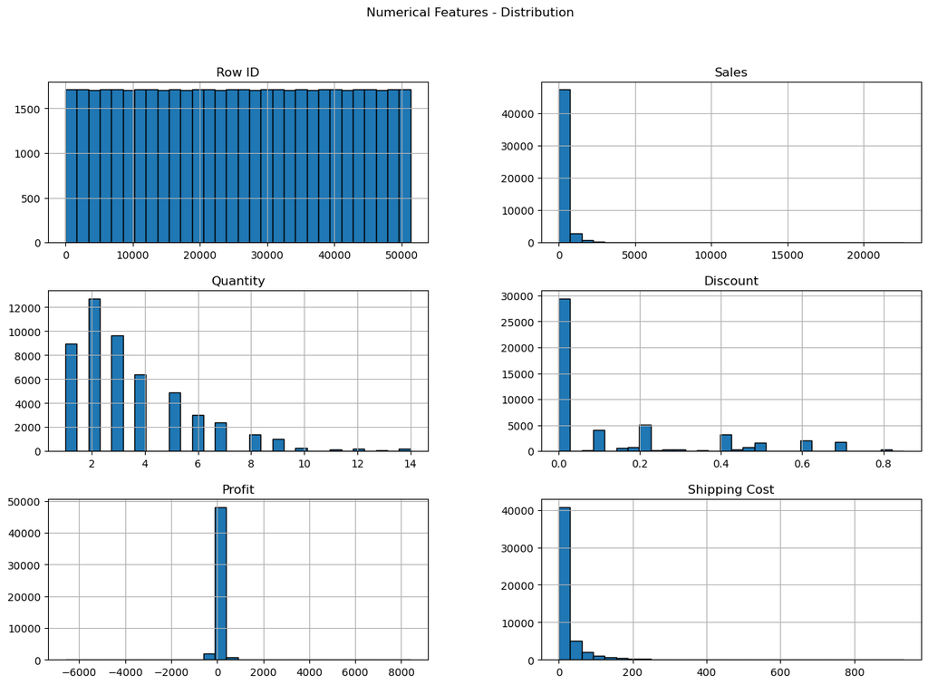

```python
df.hist(figsize=(15, 10), bins=30, edgecolor='black')
plt.suptitle('Numerical Features - Distribution')
plt.show()
```

Sales, Quantity and Shipping Cost are right skewed as we can see and this indicates the rpesence of few higher values and this is definetly affecting these features.

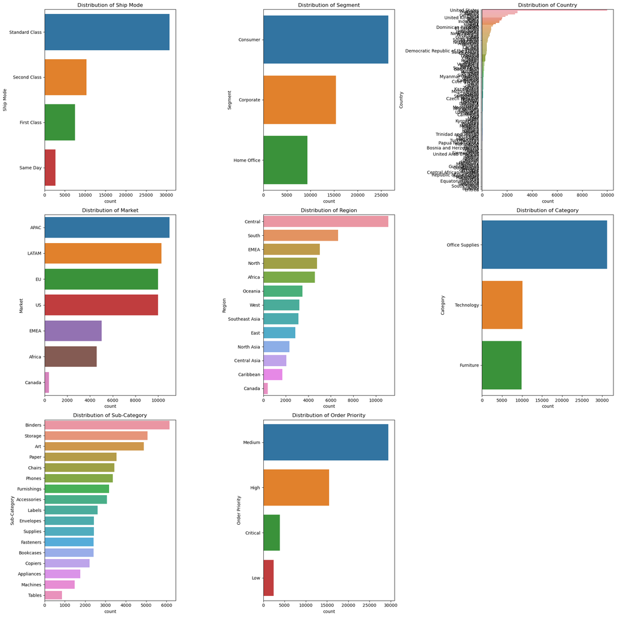

```python
categorical_columns = ['Ship Mode', 'Segment', 'Country', 'Market', 'Region', 'Category', 'Sub-Category', 'Order Priority']
plt.figure(figsize=(20, 20))

for i, col in enumerate(categorical_columns, 1):
    plt.subplot(3, 3, i)
    sns.countplot(y=col, data=df, order=df[col].value_counts().index)
    plt.title(f'Distribution of {col}')

plt.tight_layout()
plt.show()
```

Here we have an output vizulizations on how much each values in categorical variable are present.Based on these plots we can say that -

Ship Mode: Standard Class appears to be the most frequent shipping mode.

Segment: The Consumer segment seems to have the highest count, followed by Corporate and Home Office.

Country: There might be a high number of orders from United States.

Region: Central seems to be the dominant region.

Category: Office Supplies appears to be the most frequent category.

Order Priority: Medium priority orders appear to be the most frequent.

#### Cateogorical Vs Numerical

##### Sales

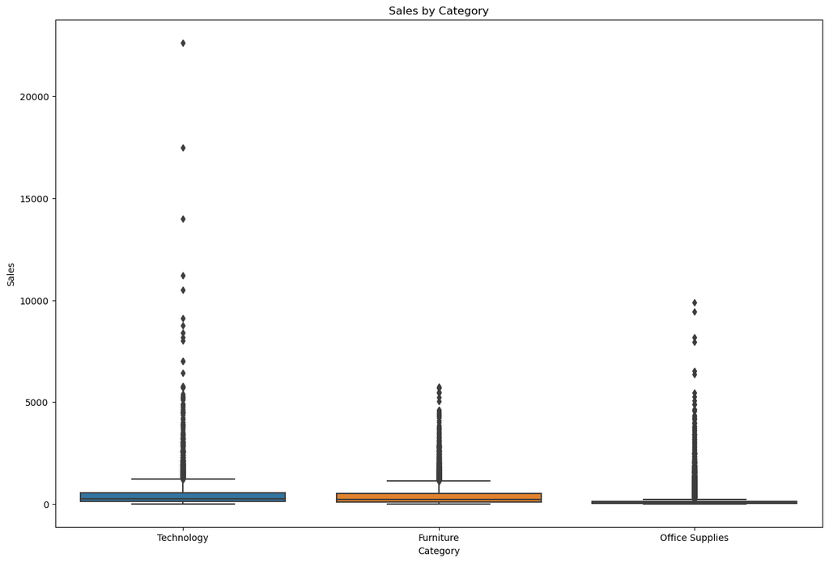

```python
plt.figure(figsize=(15, 10))
sns.boxplot(x='Category', y='Sales', data=df)
plt.title('Sales by Category')
plt.show()
```

Technology has several outliers, suggesting a few very high-value sales transactions.

Furniture has a few outliers, indicating some relatively high-value sales.

On observing closely we can see that Technology has highest median sales followed by furniture and then only office supplies.

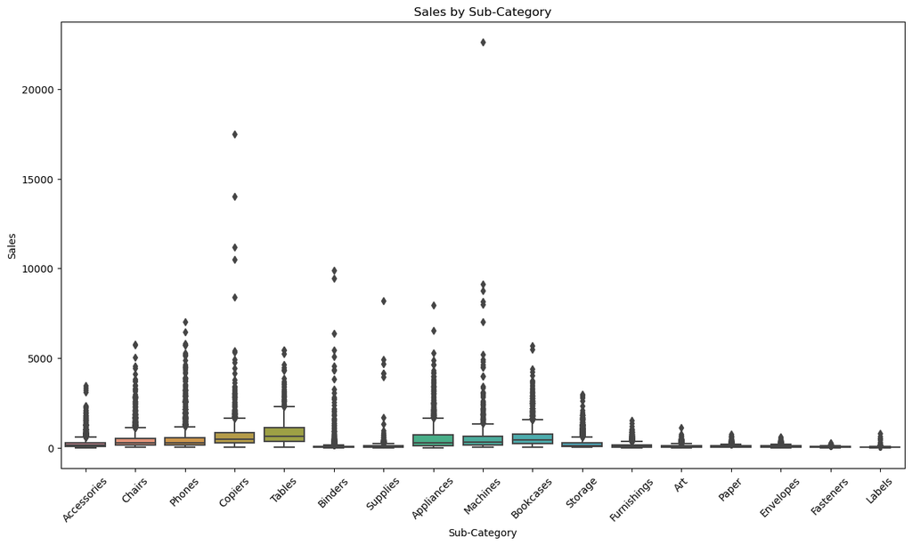

```python
plt.figure(figsize=(15, 8))
sns.boxplot(x='Sub-Category', y='Sales', data=df)
plt.title('Sales by Sub-Category')
plt.xticks(rotation=45)
plt.show()
```

Sales accross sub catogories is varying significantly.

Some have higher sales with more variabilty like phones, copiers etc and some have lower sales and less variabilty like fasteners labels etc

And when talk about outliers here few indicates high sales values.

##### Profit

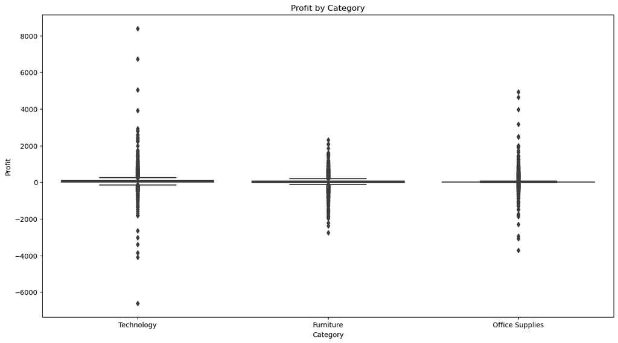

```python
plt.figure(figsize=(15, 8))
sns.boxplot(x='Category', y='Profit', data=df)
plt.title('Profit by Category')
plt.show()
```

Technology related products are tend to have higher profit values when compared to Furniture and Office Supplies.

In case of variability it is more for Technology products than for the other two.

Outliers are present on all the three catogories and through that we can understand that we have siginificant different profit margins.

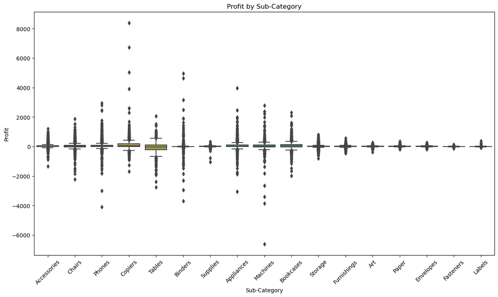

```python
plt.figure(figsize=(15, 8))
sns.boxplot(x='Sub-Category', y='Profit', data=df)
plt.title('Profit by Sub-Category')
plt.xticks(rotation=45)
plt.show()
```

Profit acrross subcatogories are varying signifincantly.

Some shows higher profit with higher varibility like copiers and there are few products which lower profit and variability in the profit.

#### Correlation

[output not shown]

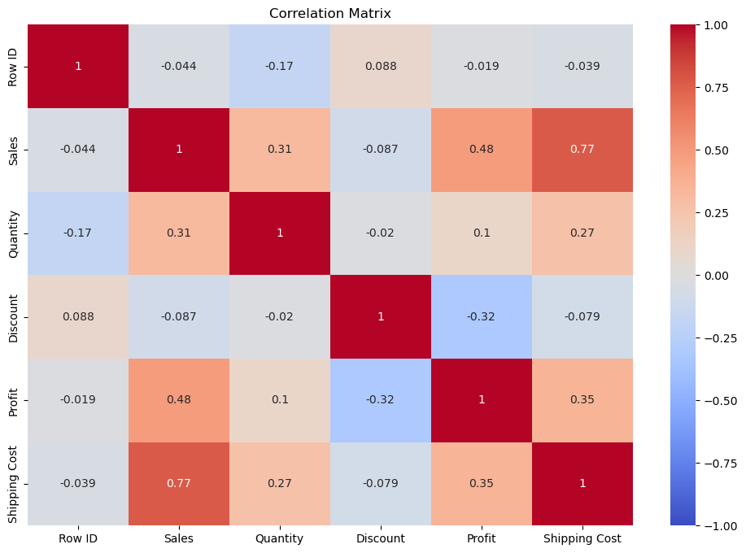

```python
corr_matrix = df.corr()
plt.figure(figsize=(12, 8))
sns.heatmap(corr_matrix, annot=True, cmap='coolwarm', vmin=-1, vmax=1)
plt.title('Correlation Matrix')
plt.show()
```

Sales and Quantity: A positive correlation (0.31), indicating that higher sales are often associated with larger quantities.

Sales and Profit: A moderate positive correlation (0.48) suggests that higher sales tend to lead to higher profits.

Shipping Cost and Sales: A strong positive correlation (0.77) indicates that higher shipping costs are often associated with higher sales.

Discount and Profit: A moderate negative correlation (-0.32) suggests that higher discounts tend to lead to lower profits.

#### PairWise Realtionships

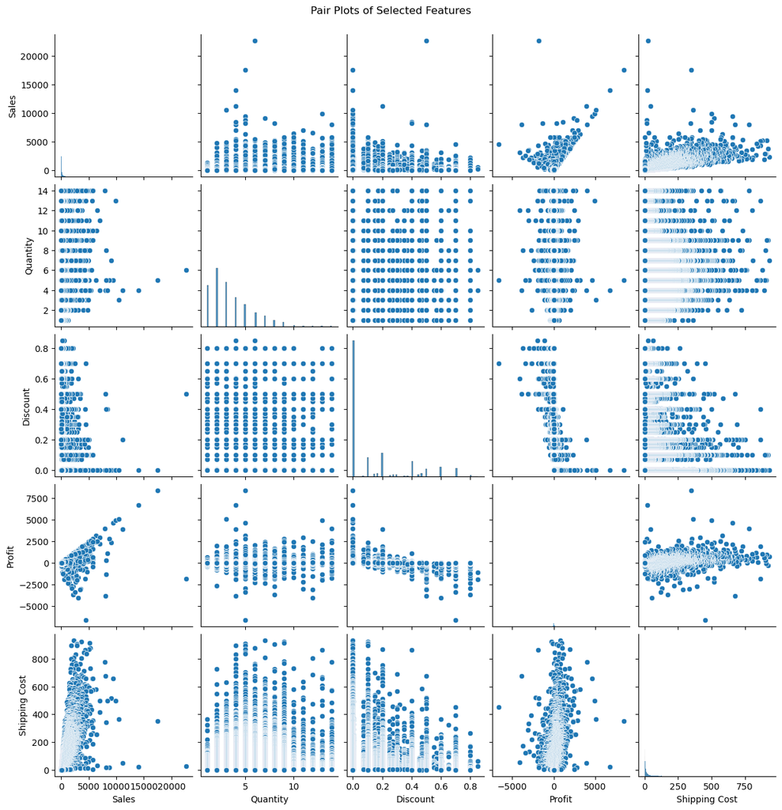

```python
sns.pairplot(df[['Sales', 'Quantity', 'Discount', 'Profit', 'Shipping Cost']])
plt.suptitle('Pair Plots of Selected Features', y=1.02)
plt.show()
```

Sales vs Quantity - There's a positive correlation, indicating that higher sales are often associated with larger quantities.

Sales vs Discount - The relationship is less clear, with some clustering of points but no strong pattern.

Sales vs Profit - A positive correlation exists, suggesting higher sales lead to higher profits.

Sales vs Shipping Cost - A strong positive correlation indicates that higher sales often involve higher shipping costs.

#### Time Series Analysis

##### Sales Over Time

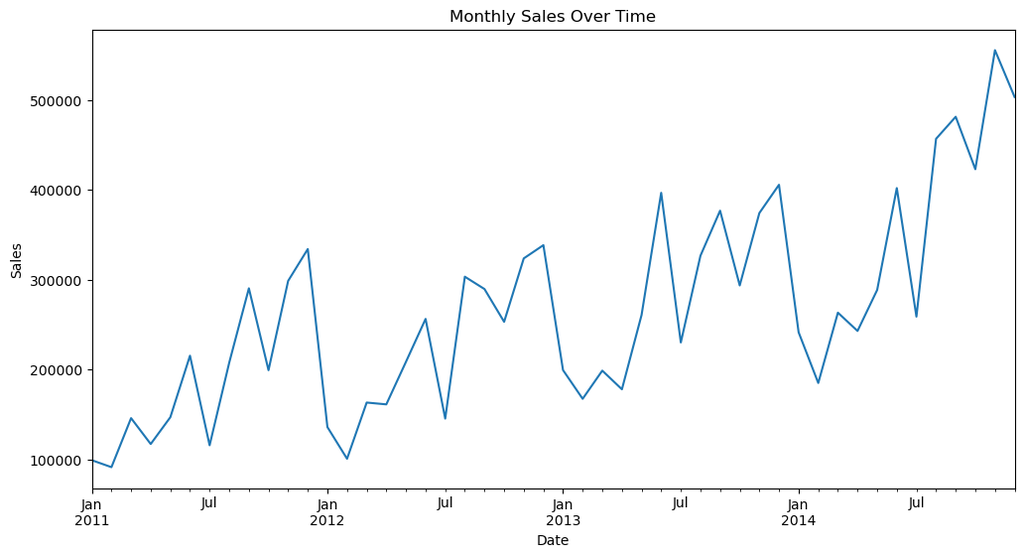

```python
df['Order Date'] = pd.to_datetime(df['Order Date'])
df.set_index('Order Date')['Sales'].resample('M').sum().plot(figsize=(12, 6))
plt.title('Monthly Sales Over Time')
plt.xlabel('Date')
plt.ylabel('Sales')
plt.show()
```

We have data from Jan 2011 - End of 2014.

There are significant ups and downs in sales over the period.

As per this we can say there might me a seaseonal trend that is existing.

Even if there are fluctuations, there seems to be an overall upward trend in sales towards the end of the period.

##### Profit Over Time

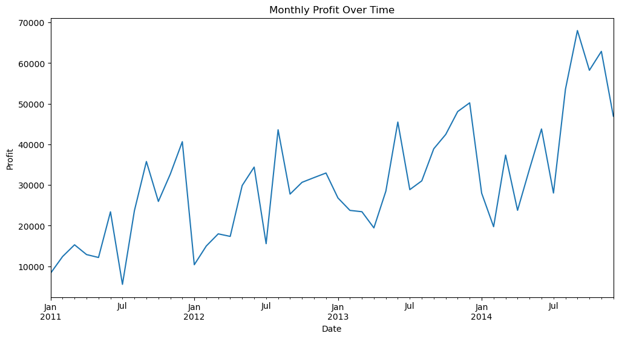

```python
df.set_index('Order Date')['Profit'].resample('M').sum().plot(figsize=(12, 6))
plt.title('Monthly Profit Over Time')
plt.xlabel('Date')
plt.ylabel('Profit')
plt.show()
```

There exist significant ups and downs in profit throughout the period.

#### Geographic Analysis

##### Sales by State

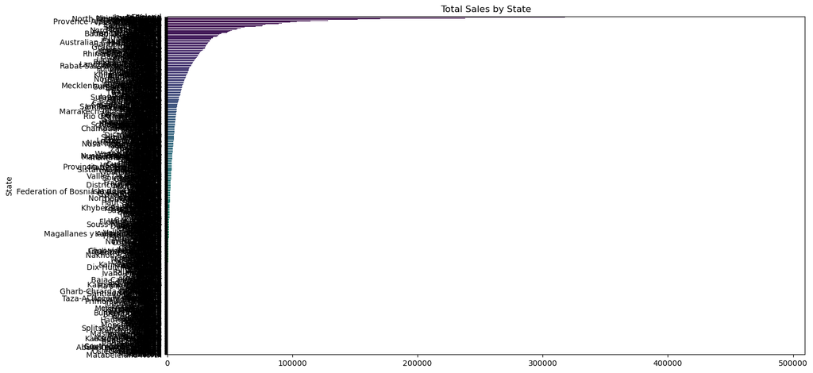

```python
plt.figure(figsize=(15, 8))
state_sales = df.groupby('State')['Sales'].sum().sort_values(ascending=False)
sns.barplot(x=state_sales.values, y=state_sales.index, palette='viridis')
plt.title('Total Sales by State')
plt.show()
```

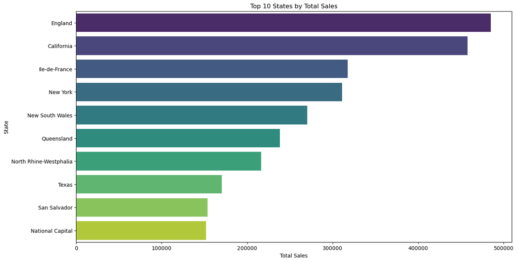

```python
top_state_sales = df.groupby('State')['Sales'].sum().sort_values(ascending=False).head(10)

plt.figure(figsize=(15, 8))
sns.barplot(x=top_state_sales.values, y=top_state_sales.index, palette='viridis')
plt.title('Top 10 States by Total Sales')
plt.xlabel('Total Sales')
plt.ylabel('State')
plt.show()
```

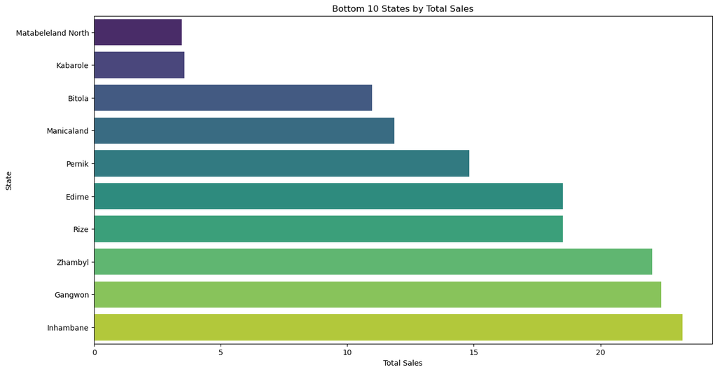

```python
bottom_state_sales = df.groupby('State')['Sales'].sum().sort_values(ascending=True).head(10)

plt.figure(figsize=(15, 8))
sns.barplot(x=bottom_state_sales.values, y=bottom_state_sales.index, palette='viridis')
plt.title('Bottom 10 States by Total Sales')
plt.xlabel('Total Sales')
plt.ylabel('State')
plt.show()
```

England has the highest sales and Matabeleland North has lowest sales.

##### Profit by State

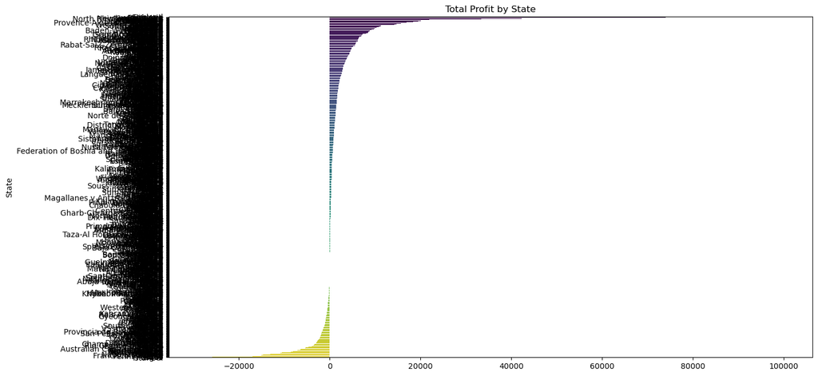

```python
plt.figure(figsize=(15, 8))
state_profit = df.groupby('State')['Profit'].sum().sort_values(ascending=False)
sns.barplot(x=state_profit.values, y=state_profit.index, palette='viridis')
plt.title('Total Profit by State')
plt.show()
```

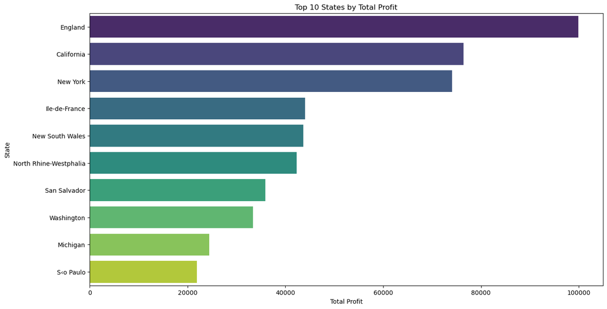

```python
top_state_profit = df.groupby('State')['Profit'].sum().sort_values(ascending=False).head(10)

plt.figure(figsize=(15, 8))
sns.barplot(x=top_state_profit.values, y=top_state_profit.index, palette='viridis')
plt.title('Top 10 States by Total Profit')
plt.xlabel('Total Profit')
plt.ylabel('State')
plt.show()
```

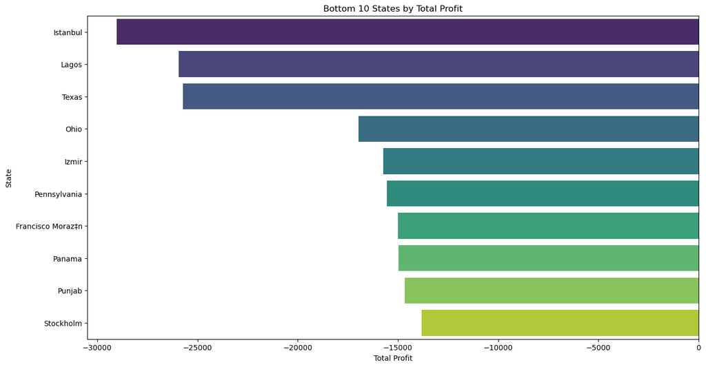

```python
bottom_state_profit = df.groupby('State')['Profit'].sum().sort_values(ascending=True).head(10)

plt.figure(figsize=(15, 8))
sns.barplot(x=bottom_state_profit.values, y=bottom_state_profit.index, palette='viridis')
plt.title('Bottom 10 States by Total Profit')
plt.xlabel('Total Profit')
plt.ylabel('State')
plt.show()
```

##### Sales - States - Categories

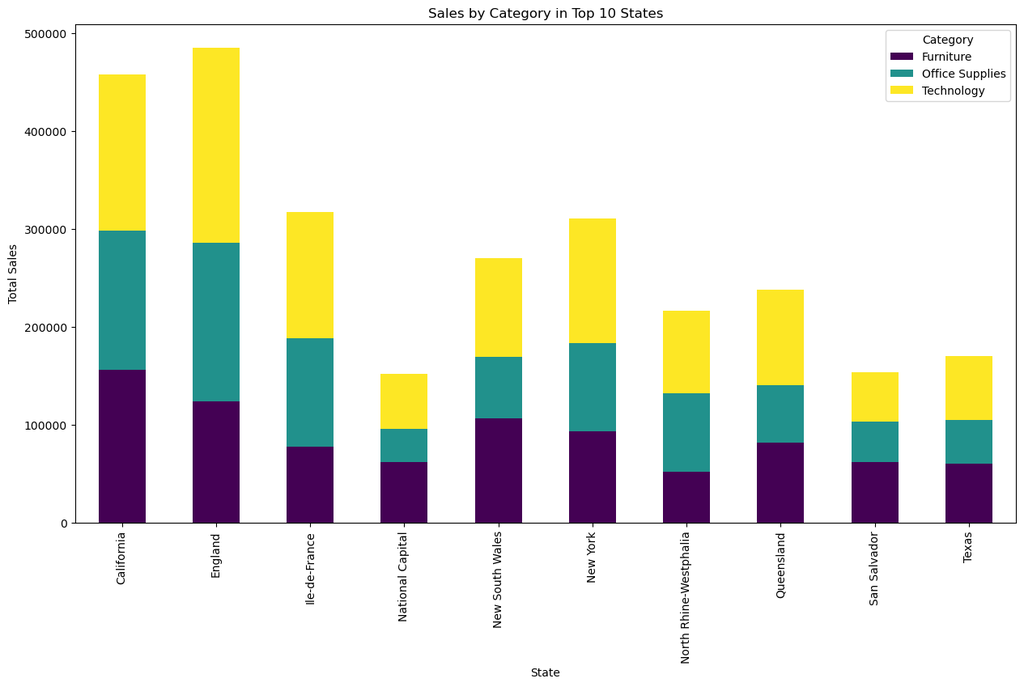

```python
top_states = df.groupby('State')['Sales'].sum().sort_values(ascending=False).head(10).index

top_states_df = df[df['State'].isin(top_states)]

state_category_sales = top_states_df.groupby(['State', 'Category'])['Sales'].sum().unstack()

state_category_sales.plot(kind='bar', stacked=True, figsize=(15, 8), colormap='viridis')
plt.title('Sales by Category in Top 10 States')
plt.xlabel('State')
plt.ylabel('Total Sales')
plt.legend(title='Category')
plt.show()
```

England and California: These two states have the highest total sales and also have a significant presence in all three product categories.

Category Dominance: Some states show a stronger presence in specific categories for instance we can see that Ile-de-France has a higher proportion of Technology sales compared to other categories.

##### Profit - States - Categories

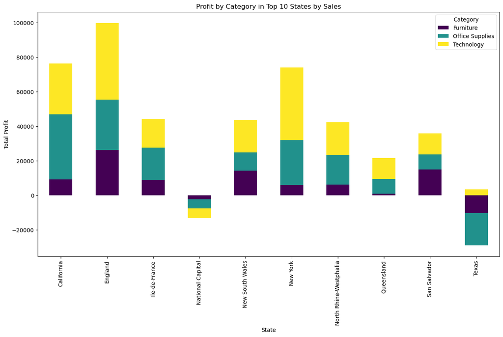

```python
state_category_profit = top_states_df.groupby(['State', 'Category'])['Profit'].sum().unstack()

state_category_profit.plot(kind='bar', stacked=True, figsize=(15, 8), colormap='viridis')
plt.title('Profit by Category in Top 10 States by Sales')
plt.xlabel('State')
plt.ylabel('Total Profit')
plt.legend(title='Category')
plt.show()
```

Some states might have higher overall profits due to a combination of strong performance across multiple categories or dominance in a particular category.

#### Customer Analysis

##### Top 10 Customers by Sales

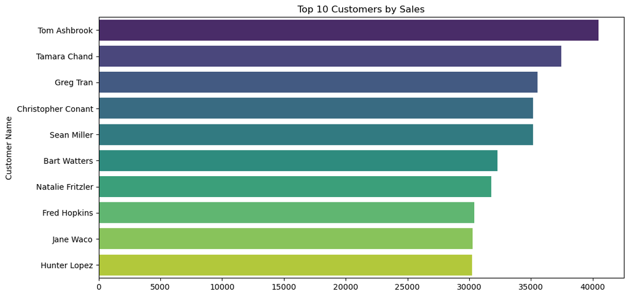

```python
top_customers_sales = df.groupby('Customer Name')['Sales'].sum().nlargest(10)
plt.figure(figsize=(12, 6))
sns.barplot(x=top_customers_sales.values, y=top_customers_sales.index, palette='viridis')
plt.title('Top 10 Customers by Sales')
plt.show()
```

##### Top 10 Customers by Profit

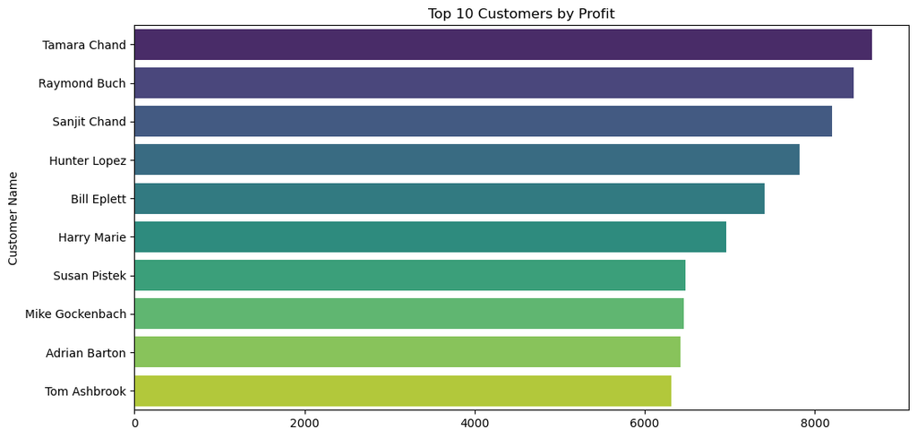

```python
top_customers_profit = df.groupby('Customer Name')['Profit'].sum().nlargest(10)
plt.figure(figsize=(12, 6))
sns.barplot(x=top_customers_profit.values, y=top_customers_profit.index, palette='viridis')
plt.title('Top 10 Customers by Profit')
plt.show()
```

##### Sales - Profit - Customer

```python
# Get the top 10 customers by Sales
top_10_sales = customer_sales_profit.nlargest(10, 'Sales')

# Get the top 10 customers by Profit
top_10_profit = customer_sales_profit.nlargest(10, 'Profit')
```

```python
# For top 10 customers by Sales
fig_sales = px.bar(top_10_sales, x='Customer ID', y='Sales', title='Top 10 Customers by Sales',
                   labels={'Sales': 'Total Sales', 'Customer ID': 'Customer ID'}, color='Sales',
                   color_continuous_scale='Viridis')
fig_sales.update_layout(xaxis_tickangle=-45)
fig_sales.show()

#For top 10 customers by Profit
fig_profit = px.bar(top_10_profit, x='Customer ID', y='Profit', title='Top 10 Customers by Profit',
                    labels={'Profit': 'Total Profit', 'Customer ID': 'Customer ID'}, color='Profit',
                    color_continuous_scale='Viridis')
fig_profit.update_layout(xaxis_tickangle=-45)
fig_profit.show()
```

[interactive chart not shown]

From these customer based analysis we can identify our most valuable customers and further for more analysis we can implement RFM and many more to improve our marketing startegies and aslo we can retain the the other customers.

#### Product Analysis

##### Top 10 Products by Sales

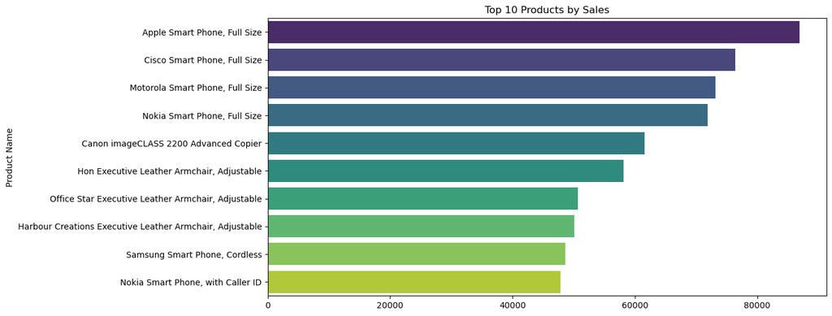

```python
top_products_sales = df.groupby('Product Name')['Sales'].sum().nlargest(10)
plt.figure(figsize=(12, 6))
sns.barplot(x=top_products_sales.values, y=top_products_sales.index, palette='viridis')
plt.title('Top 10 Products by Sales')
plt.show()
```

##### Top 10 Products by Profit

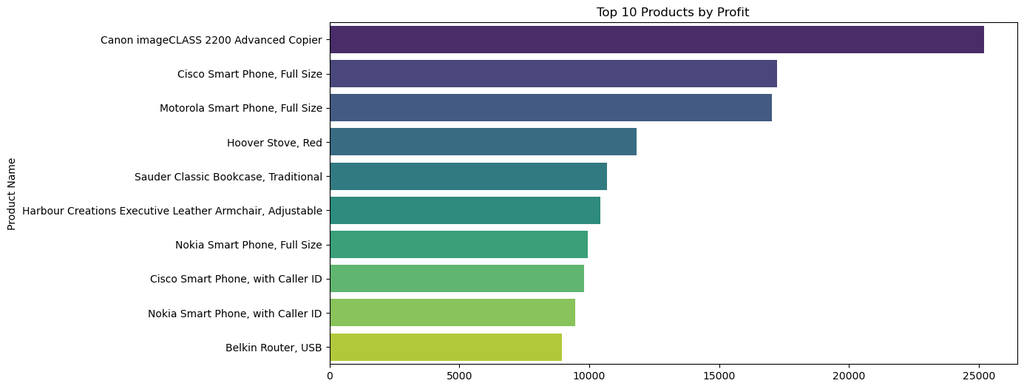

```python
top_products_profit = df.groupby('Product Name')['Profit'].sum().nlargest(10)
plt.figure(figsize=(12, 6))
sns.barplot(x=top_products_profit.values, y=top_products_profit.index, palette='viridis')
plt.title('Top 10 Products by Profit')
plt.show()
```

Both shows which products gives us more profit and sales

#### Sales and Profit By Cateogory

```python
# Group by Category and calculate total Sales, Profit, and Order Count
category_sales_profit = df.groupby('Category').agg({'Sales': 'sum', 'Profit': 'sum', 'Order ID': 'count'}).reset_index()
category_sales_profit.rename(columns={'Order ID': 'Order Count'}, inplace=True)

fig = px.scatter(category_sales_profit, x='Sales', y='Profit', size='Order Count', color='Category',
                 hover_name='Category', title='Categories by Sales and Profit',
                 labels={'Sales': 'Total Sales', 'Profit': 'Total Profit', 'Order Count': 'Number of Orders'},
                 size_max=60, color_discrete_sequence=px.colors.qualitative.Vivid)

fig.show()
```

[interactive chart not shown]

Here we can see Technology is the one which shows as highest sales and highest profit.

#### Sales and Profit by Sub Category

```python
# Group by Sub-Category and calculate total Sales, Profit, and Order Count
subcategory_sales_profit = df.groupby('Sub-Category').agg({'Sales': 'sum', 'Profit': 'sum', 'Order ID': 'count'}).reset_index()
subcategory_sales_profit.rename(columns={'Order ID': 'Order Count'}, inplace=True)

fig = px.scatter(subcategory_sales_profit, x='Sales', y='Profit', size='Order Count', color='Sub-Category',
                 hover_name='Sub-Category', title='Sub-Categories by Sales and Profit',
                 labels={'Sales': 'Total Sales', 'Profit': 'Total Profit', 'Order Count': 'Number of Orders'},
                 size_max=60, color_discrete_sequence=px.colors.qualitative.Vivid)

fig.show()
```

[interactive chart not shown]

Here we can observe phones have comparitatively higher sales and and profit but copiers do show higher profit levels than in sales when compared with phones.

#### Sales and Profit by Segment

```python
# Group by Segment and calculate total Sales, Profit, and Order Count
segment_sales_profit = df.groupby('Segment').agg({'Sales': 'sum', 'Profit': 'sum', 'Order ID': 'count'}).reset_index()
segment_sales_profit.rename(columns={'Order ID': 'Order Count'}, inplace=True)

fig = px.scatter(segment_sales_profit, x='Sales', y='Profit', size='Order Count', color='Segment',
                 hover_name='Segment', title='Segments by Sales and Profit',
                 labels={'Sales': 'Total Sales', 'Profit': 'Total Profit', 'Order Count': 'Number of Orders'},
                 size_max=60, color_discrete_sequence=px.colors.qualitative.Plotly)

fig.show()
```

[interactive chart not shown]

Regular consumers are are highest selling and profit making point.

#### Interpretations

Sales Trends: Sales are generally increasing over time, showing that the business is growing. There are seasonal ups and downs, which might be linked to external factors like holidays or market conditions.

Profit Trends: Profit is more variable than sales, with periods of growth and sharp declines, suggesting issues with cost control or pricing.

Regional Sales: Sales are focused in a few key states, indicating strong markets there but also opportunities for growth in other states.

Category Performance: Technology and Office Supplies categories are performing well in both sales and profits. Furniture might need more investigation due to potential issues with profitability.

#### Suggestions

Profitability: The inconsistency in profit margins across states and product categories suggests areas for improvement in cost control or pricing strategies.

Market Expansion: While the top 10 states contribute significantly to sales, exploring untapped markets could lead to growth.

Product Mix: Analyzing the sales and profit performance of each product category can help optimize product offerings.

Seasonal Impact: Understanding the seasonal patterns in sales and profit can aid in inventory management, staffing, and promotional planning.